# Two Variables: Qualitative

Author

Ashley Ericka B. Ilarde

Published

November 12, 2026

# The Data

```r
# load packages
library(tidyverse)
library(knitr)
library(gtsummary)
library(ggstatsplot)
library(downlit)
library(broom)
library(here)

# load the data
df <- read_csv(here("data","Data_Results.csv"))

df <- df|>
  mutate(
   college=factor(
      college,
      levels = c("CA","CAS","CBE","CFERM","CHE","CITE","COE","CTE","CVM"),
      ordered = TRUE
    )

  )|>
  select(
    "college",
    "prefer"
  )
```

## A Comparative Study of Digital and Printed Learning Resources Among NVSU Students

The Data set is gathered from 68 students with 2 variable.

```r
df |>
  head() |> # getting the first six rows of the data
  kable(col.names = c("College", "Learning Resources Preference")) # creating a table
```

Table 1: The first 6 observations of the data set.

| College | Learning Resources Preference |
| --- | --- |
| CA | Digital learning resources |
| CA | Both equally |
| CA | Both equally |
| CA | Printed learning resources |
| CA | Digital learning resources |
| CAS | Printed learning resources |

## Descriptive Statistics

The data aims to describe the students’ learning resource preferences across nine different colleges, namely CA, CAS, CBE, CFERM, CHE, CITE, COE, CTE, and CVM. Based on the first six observations, most students showed different preferences regarding the use of learning materials. Two students preferred both digital and printed learning resources equally, while two preferred digital learning resources and two preferred printed learning resources. This suggests that students have varied preferences when it comes to choosing learning materials, with no single type dominating the first six observations. The data, which consists of 68 student respondents, will help determine the overall learning resource preference among students from the different colleges.

```r
df |>
  tbl_summary(
    by = prefer,
    include = college
  )
```

Table 2: Summary statistics of `college` when grouped according to `prefer`.

| **Characteristic** | **Both equally** N = 21<sup>1</sup> | **Digital learning resources** N = 27<sup>1</sup> | **Printed learning resources** N = 20<sup>1</sup> |
| --- | --- | --- | --- |
| college |  |  |  |
| CA | 2 (9.5%) | 2 (7.4%) | 1 (5.0%) |
| CAS | 1 (4.8%) | 1 (3.7%) | 1 (5.0%) |
| CBE | 3 (14%) | 6 (22%) | 1 (5.0%) |
| CFERM | 1 (4.8%) | 5 (19%) | 2 (10%) |
| CHE | 1 (4.8%) | 0 (0%) | 6 (30%) |
| CITE | 1 (4.8%) | 4 (15%) | 3 (15%) |
| COE | 5 (24%) | 2 (7.4%) | 3 (15%) |
| CTE | 5 (24%) | 6 (22%) | 3 (15%) |
| CVM | 2 (9.5%) | 1 (3.7%) | 0 (0%) |

<sup>1</sup> n (%)

```r
df |>
tbl_cross(
row = college,
col = prefer,
percent = 'column',
margin = c("row", "column"),
label = list(
college ~ "College",
prefer ~ "Learning Resources Preference"
)
)
```

|  | Learning Resources Preference Both equally | Learning Resources Preference Digital learning resources | Learning Resources Preference Printed learning resources | Total |  |
| --- | --- | --- | --- | --- | --- |
| College |  |  |  |  |  |
| CA | 2 (9.5%) | 2 (7.4%) | 1 (5.0%) | 5 (7.4%) |  |
| CAS | 1 (4.8%) | 1 (3.7%) | 1 (5.0%) | 3 (4.4%) |  |
| CBE | 3 (14%) | 6 (22%) | 1 (5.0%) | 10 (15%) |  |
| CFERM | 1 (4.8%) | 5 (19%) | 2 (10%) | 8 (12%) |  |
| CHE | 1 (4.8%) | 0 (0%) | 6 (30%) | 7 (10%) |  |
| CITE | 1 (4.8%) | 4 (15%) | 3 (15%) | 8 (12%) |  |
| COE | 5 (24%) | 2 (7.4%) | 3 (15%) | 10 (15%) |  |
| CTE | 5 (24%) | 6 (22%) | 3 (15%) | 14 (21%) |  |
| CVM | 2 (9.5%) | 1 (3.7%) | 0 (0%) | 3 (4.4%) |  |
| Total | 21 (100%) | 27 (100%) | 20 (100%) | 68 (100%) |  |

# Hypothesis Testing

Research Question

Does students’ college program have a significant relationship with their preferred learning resources?

## Hypothesis and Test Statistics

```r
# Create contingency table
observed <- table(df$college, df$prefer)

# Perform chi-squared test
chi_test <- chisq.test(observed)

# Extract the expected counts
expected <- chi_test$expected

# View expected counts
expected |>
  as_tibble() |>
  mutate(
    " " = c("CA","CAS","CBE","CFERM","CHE","CITE","COE","CTE","CVM")
  ) |>
  relocate(" ", .before = 1) |>
  mutate(across(where(is.numeric), ~ round(.x, 2))) |>
  kable()
```

Table 3: Expected counts.

|  | Both equally | Digital learning resources | Printed learning resources |
| --- | --- | --- | --- |
| CA | 1.54 | 1.99 | 1.47 |
| CAS | 0.93 | 1.19 | 0.88 |
| CBE | 3.09 | 3.97 | 2.94 |
| CFERM | 2.47 | 3.18 | 2.35 |
| CHE | 2.16 | 2.78 | 2.06 |
| CITE | 2.47 | 3.18 | 2.35 |
| COE | 3.09 | 3.97 | 2.94 |
| CTE | 4.32 | 5.56 | 4.12 |
| CVM | 0.93 | 1.19 | 0.88 |

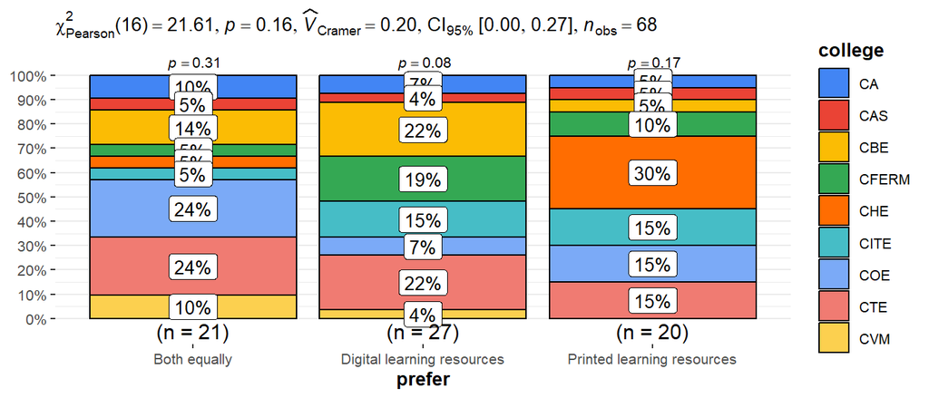

Figure 1: Bar chart and test statistics.

```r
ggbarstats(
  data = df,
  x = college,
  y = prefer,
  bf.message = FALSE,
  legend.title = "college"
)
```

### Conclusion

The results show that students from different colleges have varying preferences for learning resources, including digital, printed, and both equally. However, the chi-square test (p = 0.16) indicates no statistically significant relationship between college affiliation and learning resource preference. This suggests that students’ college programs do not significantly influence their choice of learning resources.